# Safia Jiwani, MSPH

## About me:

I am a first year PhD student in International Health. I am from Burundi (East Africa) and have been living in Baltimore for the past six years. I received by Bachelor’s degree in Human Nutrition from McGill University, and my master’s degree in International Health at JHSPH.

## My research:

My research focuses on improving existing coverage measures of maternal and newborn health services in low- and middle-income countries. I am currently working on assessing facility readiness of antenatal care and generating readiness-adjusted antenatal care coverage estimates, which I think are more informative than crude coverage estimates.

## Why I’m taking this course:

I use Stata for all my analyses- and I love it. I have been trying to learn R for a while now, but it’s a very steep learning curve. I hope this course will make me more comfortable with writing R code, conducting analyses and making data visualizations.

## Some fun facts about myself:

1. I love languages. I speak seven languages (I’m not fluent in all of them though!).
2. I have lived in 5 countries: Burundi, Tanzania, Canada, Peru, and the US.
3. I have never been camping!
4. I am terrified of taking this course given my very basic R coding skills. Yikes!
5. I recently traveled to Turkey for a vacation. I visited the parliament building of the world’s first federation, in Patara. I highly recommend visiting this site! Here’s a cool photo of my visit:

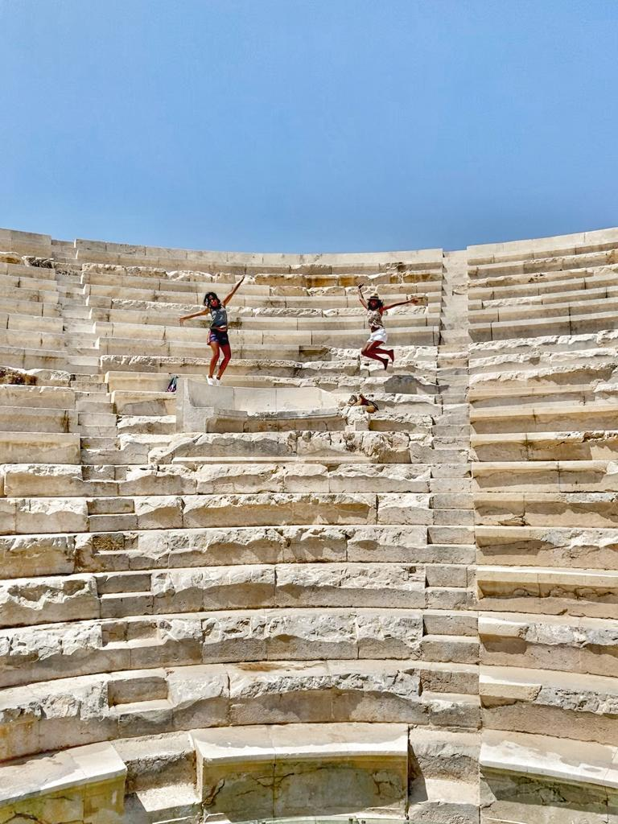

*More information on the ancient city of Patara, Turkey:*

https://www.youtube.com/watch?v=2FMYkGAFdz8